#### **Universidad Tecnológica de Panamá**

##### Maestría de Analítica de Datos

##### Profesor: Juan Marcos Castillo

##### Aquino Rodríguez

**Selección del Conjunto de Datos.**

**Exploración del dataset.**  
*Se quitan lo separadores de miles para dejar los datos enteros o decimales*

```
##   Year Month  Dom_Pax Int_Pax      Pax Dom_Flt Int_Flt    Flt  Dom_RPM  Int_RPM
## 1 2003     1 43032450 4905830 47938280  785160   57667 842827 36211422 12885980
## 2 2003     2 41166780 4245366 45412146  690351   51259 741610 34148439 10715468
## 3 2003     3 49992700 5008613 55001313  797194   58926 856120 41774564 12567068
## 4 2003     4 47033260 4345444 51378704  766260   55005 821265 39465980 10370592
## 5 2003     5 49152352 4610834 53763186  789397   55265 844662 41001934 11575026
## 6 2003     6 52209516 5411504 57621020  798351   58225 856576 44492972 13918185
##        RPM  Dom_ASM  Int_ASM      ASM Dom_LF Int_LF    LF
## 1 49097402 56191300 17968572 74159872  64.44  71.71 66.20
## 2 44863907 50088434 15587880 65676314  68.18  68.74 68.31
## 3 54341633 57592901 17753174 75346075  72.53  70.79 72.12
## 4 49836572 54639679 15528761 70168440  72.23  66.78 71.02
## 5 52576960 55349897 15629821 70979718  74.08  74.06 74.07
## 6 58411157 56555517 17191579 73747096  78.67  80.96 79.20
```

```
## 'data.frame':    249 obs. of  17 variables:
##  $ Year   : int  2003 2003 2003 2003 2003 2003 2003 2003 2003 2003 ...
##  $ Month  : int  1 2 3 4 5 6 7 8 9 10 ...
##  $ Dom_Pax: num  43032450 41166780 49992700 47033260 49152352 ...
##  $ Int_Pax: num  4905830 4245366 5008613 4345444 4610834 ...
##  $ Pax    : num  47938280 45412146 55001313 51378704 53763186 ...
##  $ Dom_Flt: num  785160 690351 797194 766260 789397 ...
##  $ Int_Flt: num  57667 51259 58926 55005 55265 ...
##  $ Flt    : num  842827 741610 856120 821265 844662 ...
##  $ Dom_RPM: num  36211422 34148439 41774564 39465980 41001934 ...
##  $ Int_RPM: num  12885980 10715468 12567068 10370592 11575026 ...
##  $ RPM    : num  49097402 44863907 54341633 49836572 52576960 ...
##  $ Dom_ASM: num  56191300 50088434 57592901 54639679 55349897 ...
##  $ Int_ASM: num  17968572 15587880 17753174 15528761 15629821 ...
##  $ ASM    : num  74159872 65676314 75346075 70168440 70979718 ...
##  $ Dom_LF : num  64.4 68.2 72.5 72.2 74.1 ...
##  $ Int_LF : num  71.7 68.7 70.8 66.8 74.1 ...
##  $ LF     : num  66.2 68.3 72.1 71 74.1 ...
```

```
##       Year          Month           Dom_Pax            Int_Pax
##  Min.   :2003   Min.   : 1.000   Min.   : 2877290   Min.   :  136609
##  1st Qu.:2008   1st Qu.: 3.000   1st Qu.:50982170   1st Qu.: 6395022
##  Median :2013   Median : 6.000   Median :56200104   Median : 7419187
##  Mean   :2013   Mean   : 6.446   Mean   :55209710   Mean   : 7392209
##  3rd Qu.:2018   3rd Qu.: 9.000   3rd Qu.:60892131   3rd Qu.: 8567847
##  Max.   :2023   Max.   :12.000   Max.   :75378157   Max.   :12432615
##       Pax              Dom_Flt          Int_Flt           Flt
##  Min.   : 3013899   Min.   :217262   Min.   : 4996   Min.   :222280
##  1st Qu.:57664576   1st Qu.:662000   1st Qu.:61615   1st Qu.:727898
##  Median :63899130   Median :709933   Median :66557   Median :779011
##  Mean   :62601919   Mean   :706751   Mean   :64736   Mean   :771487
##  3rd Qu.:69447429   3rd Qu.:781804   3rd Qu.:71924   3rd Qu.:848650
##  Max.   :87810772   Max.   :890938   Max.   :82681   Max.   :964102
##     Dom_RPM            Int_RPM              RPM               Dom_ASM
##  Min.   : 2551127   Min.   :  356762   Min.   :  2907889   Min.   :19489079
##  1st Qu.:44580290   1st Qu.:16602844   1st Qu.: 61825679   1st Qu.:56555517
##  Median :49857937   Median :19689006   Median : 69005186   Median :60889086
##  Mean   :49578034   Mean   :19181027   Mean   : 68759061   Mean   :61318217
##  3rd Qu.:55682567   3rd Qu.:22667597   3rd Qu.: 78039874   3rd Qu.:66268767
##  Max.   :72267904   Max.   :31376000   Max.   :103643904   Max.   :81997399
##     Int_ASM              ASM                Dom_LF          Int_LF
##  Min.   : 1541419   Min.   : 21030499   Min.   :13.09   Min.   :23.15
##  1st Qu.:21731193   1st Qu.: 79197800   1st Qu.:77.72   1st Qu.:76.43
##  Median :24645715   Median : 85051909   Median :82.12   Median :79.91
##  Mean   :24139025   Mean   : 85457242   Mean   :79.94   Mean   :77.30
##  3rd Qu.:27705349   3rd Qu.: 92551868   3rd Qu.:85.24   3rd Qu.:82.93
##  Max.   :35326191   Max.   :117312202   Max.   :89.96   Max.   :89.44
##        LF
##  Min.   :13.83
##  1st Qu.:76.94
##  Median :81.58
##  Mean   :79.29
##  3rd Qu.:84.07
##  Max.   :89.14
```

*Se identifican si hay valores nulos*

```
## [1] "Year tiene 0 nulos"
## [1] "Month tiene 0 nulos"
## [1] "Dom_Pax tiene 0 nulos"
## [1] "Int_Pax tiene 0 nulos"
## [1] "Pax tiene 0 nulos"
## [1] "Dom_Flt tiene 0 nulos"
## [1] "Int_Flt tiene 0 nulos"
## [1] "Flt tiene 0 nulos"
## [1] "Dom_RPM tiene 0 nulos"
## [1] "Int_RPM tiene 0 nulos"
## [1] "RPM tiene 0 nulos"
## [1] "Dom_ASM tiene 0 nulos"
## [1] "Int_ASM tiene 0 nulos"
## [1] "ASM tiene 0 nulos"
## [1] "Dom_LF tiene 0 nulos"
## [1] "Int_LF tiene 0 nulos"
## [1] "LF tiene 0 nulos"
```

*Se valida si hay registros duplicados*

```
## [1] "Cantidad de duplicados (año y mes): 0"
```

**Gráficos para ver distribución de la data**

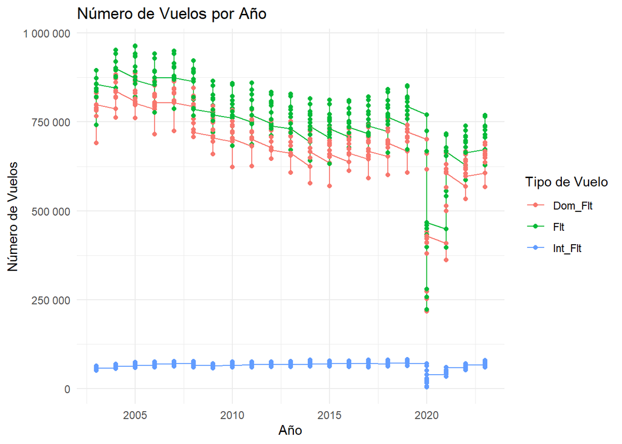

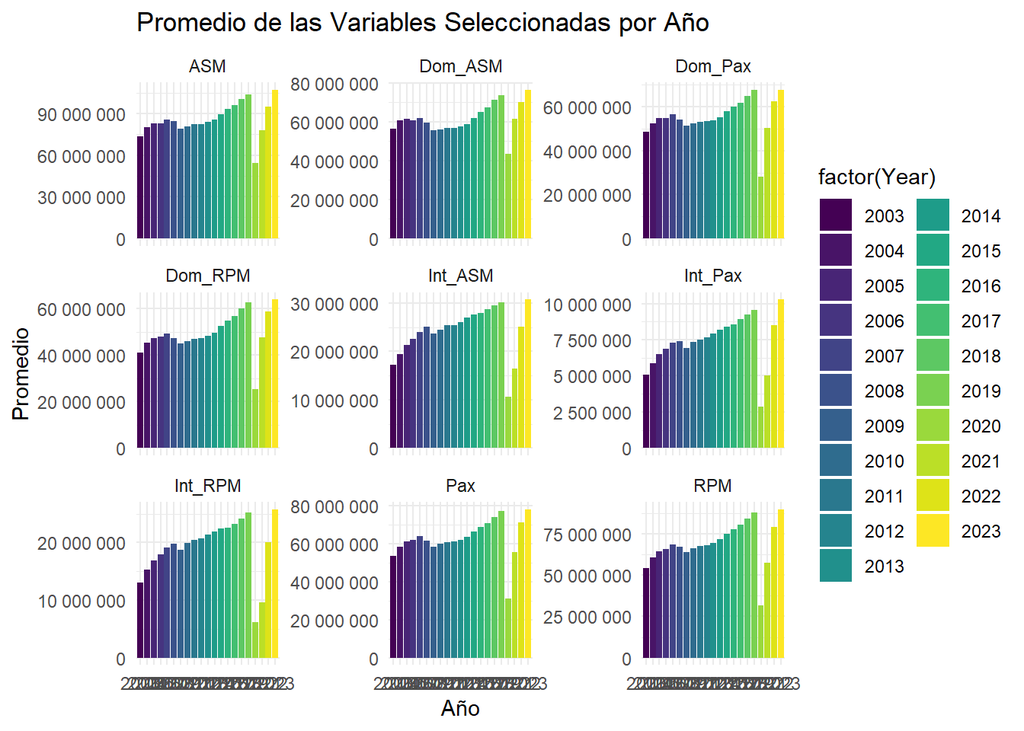

**Matriz de Correlación de la variables**

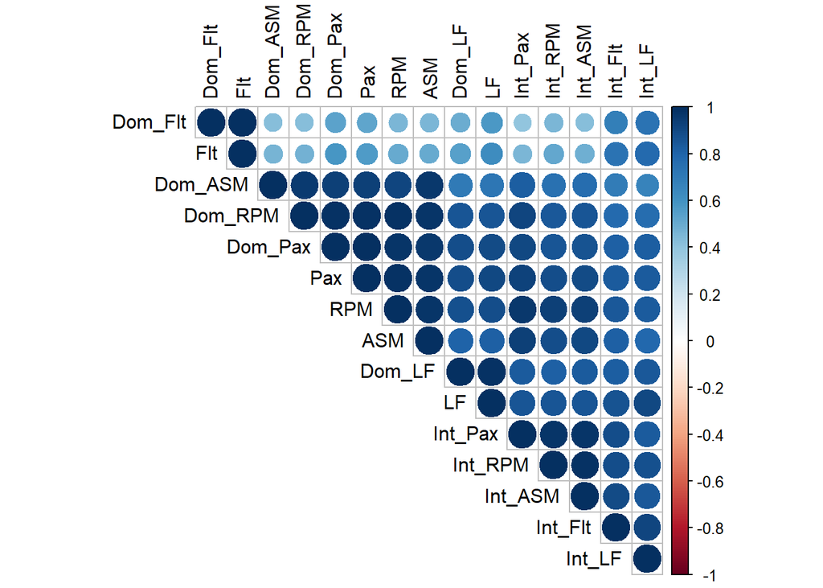

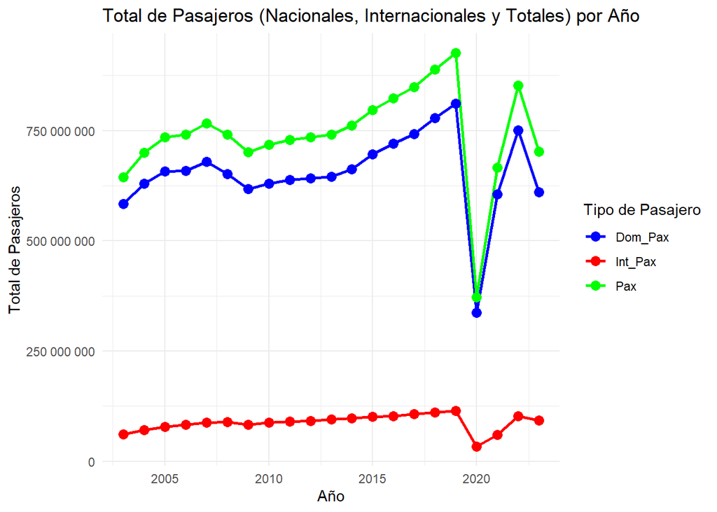

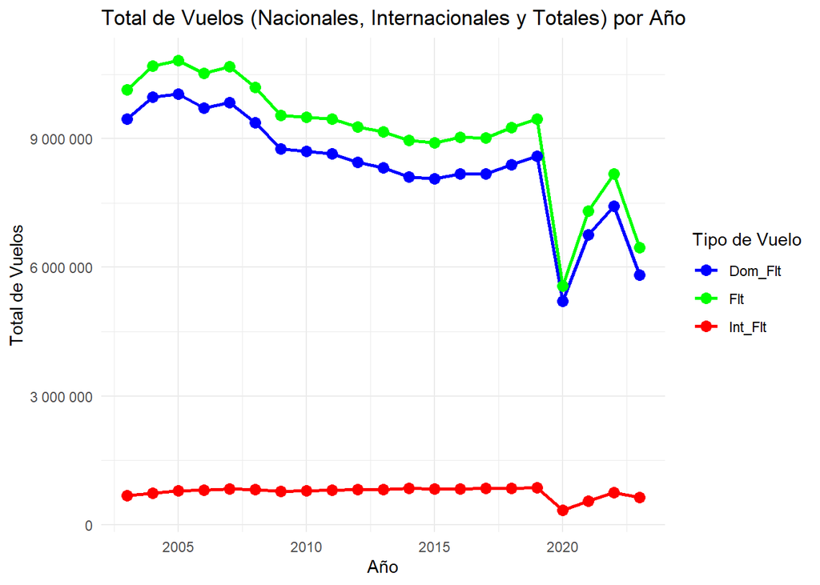

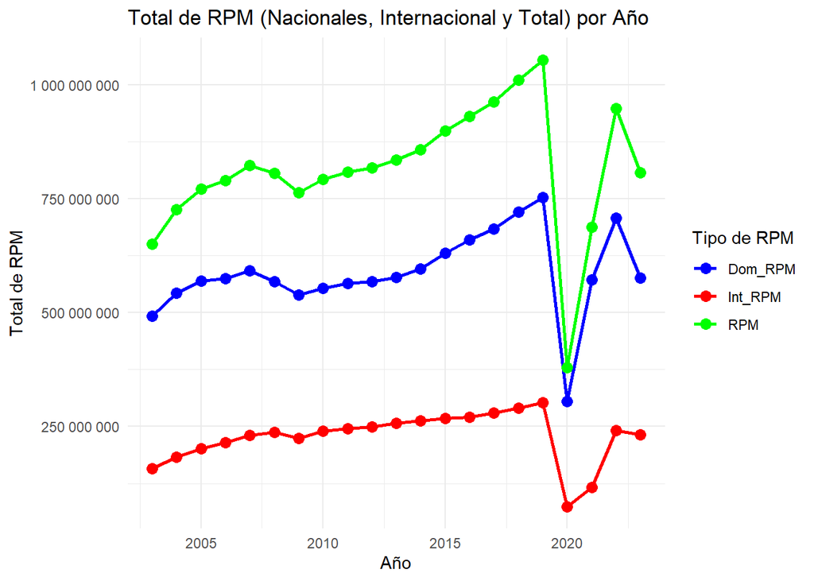

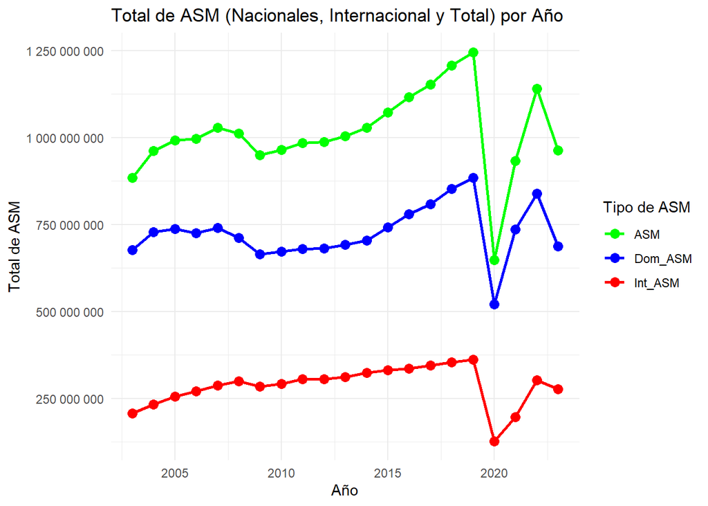

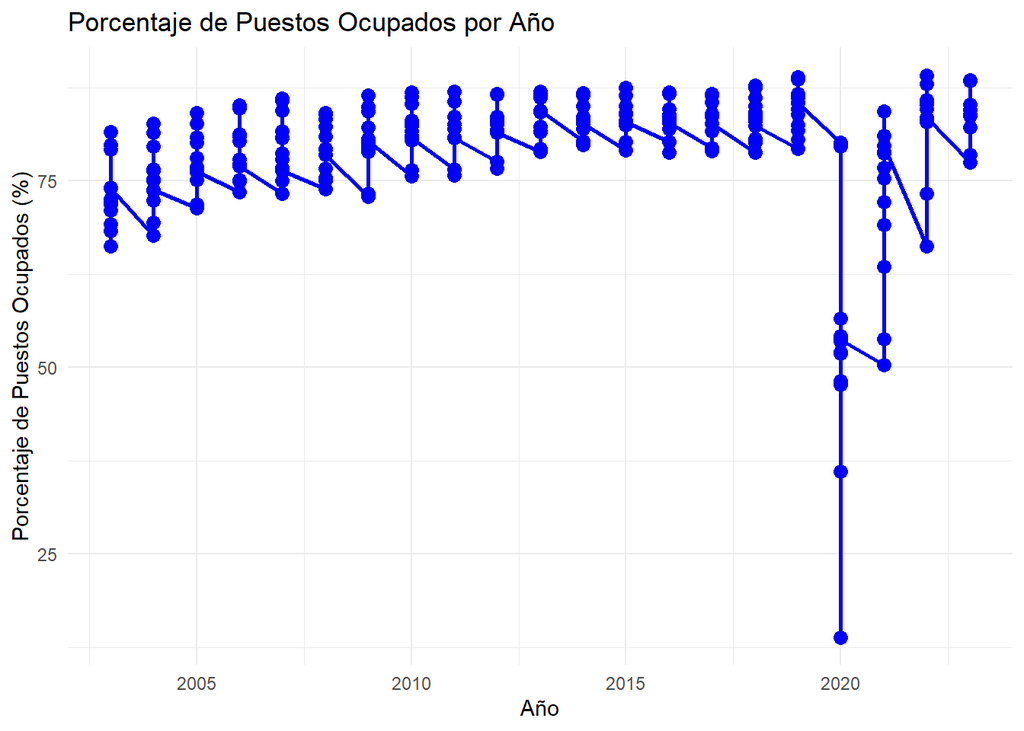

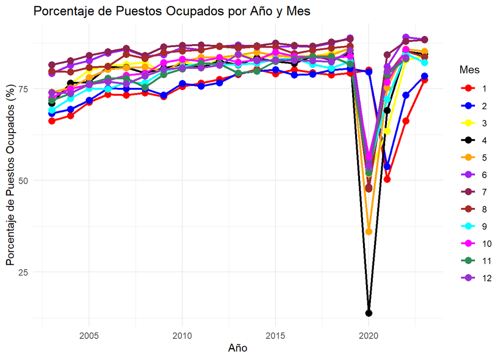

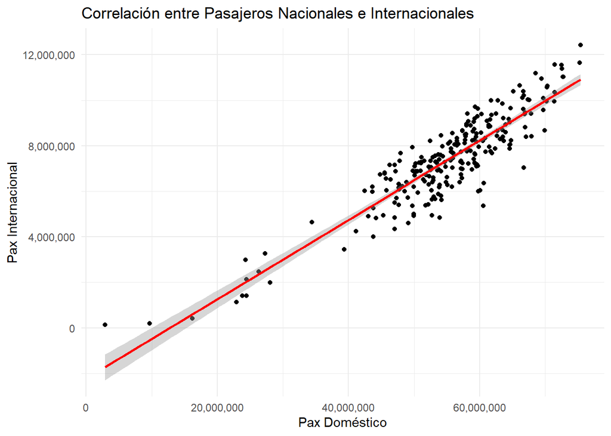

```
## [1] "Coeficiente de correlación entre Pasajeros Naciones e Internacionales: 0.901006649142015"
```

*La siguiente gráfica muestra un comporativo de comportamientos de la cantidad de pasajeros*

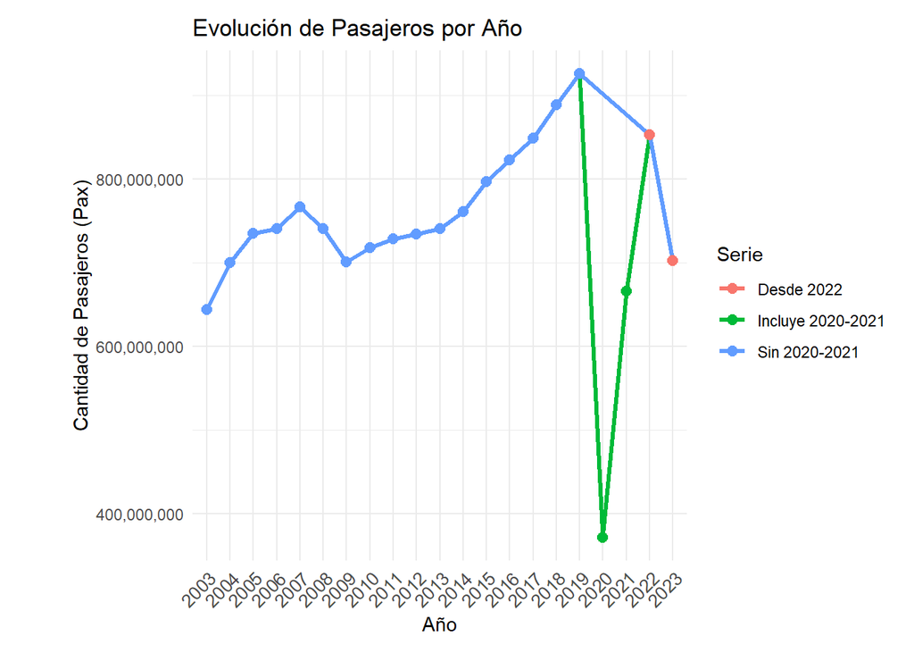

*Esta gráfica muestra el comportamiento total de los pasajeros por año*

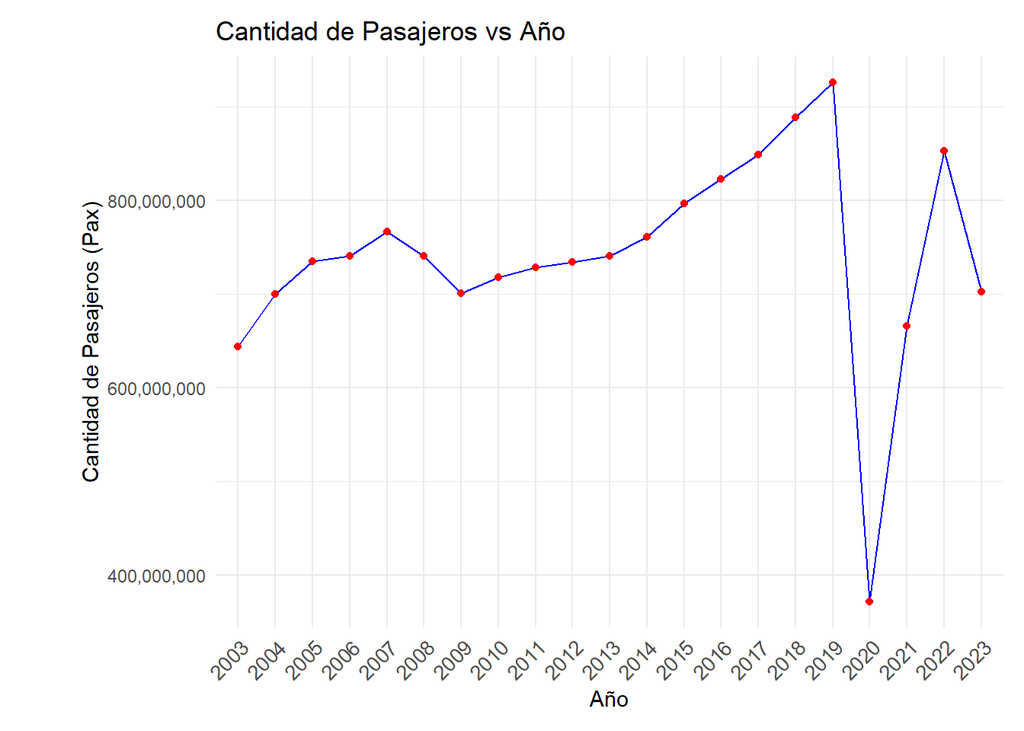

*Esta gráfica muestra el comportamiento total de los pasajeros exluyendo 2020 y 2021 por la pandemia*

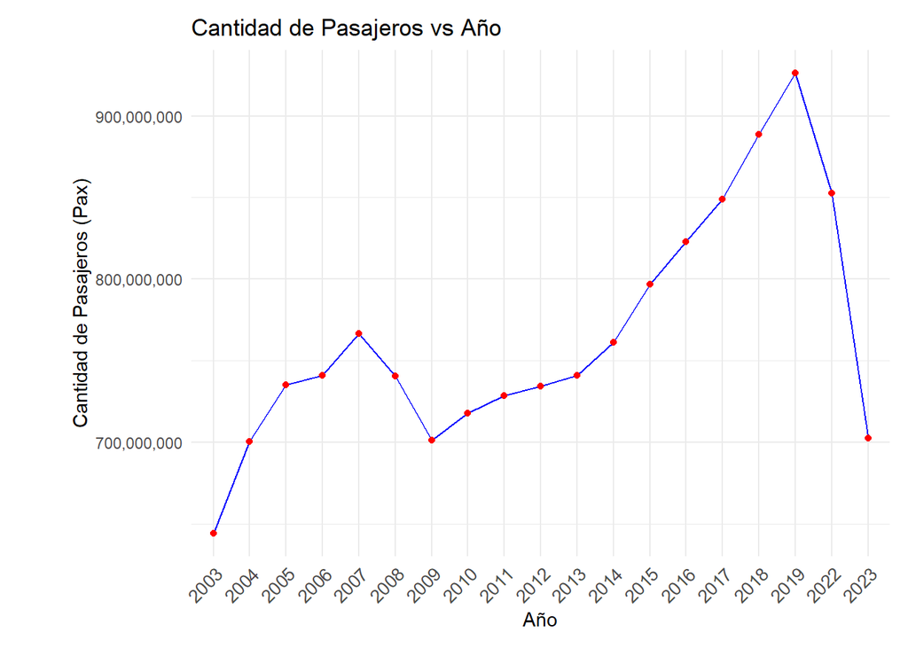

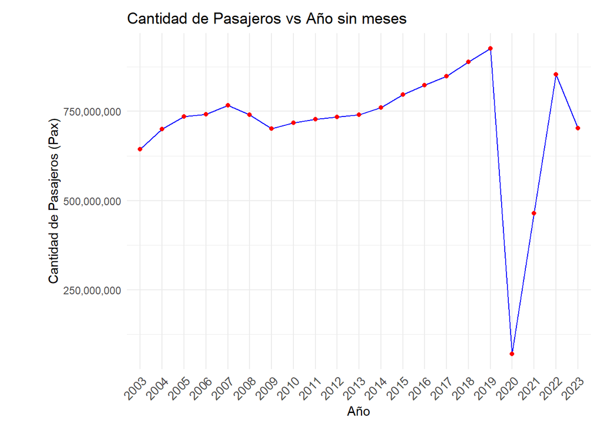

*Esta gráfica muestra el comportamiento total de los pasajero desde el 2022*

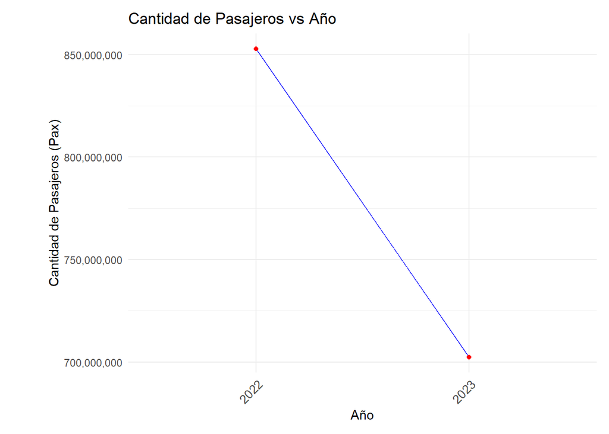

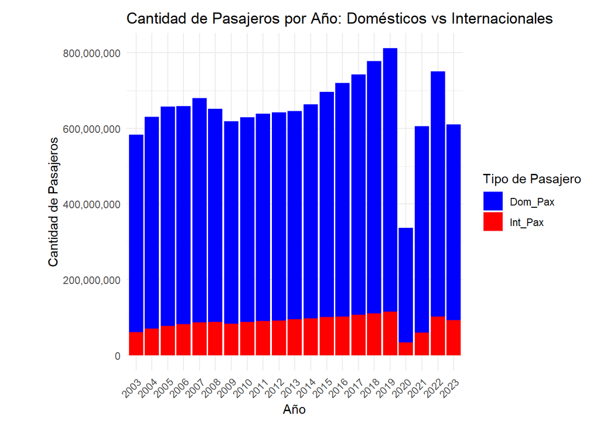

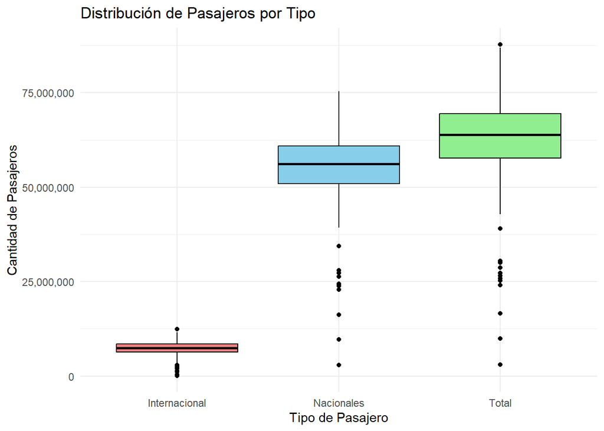

```
##   Year Month  Dom_Pax Int_Pax      Pax Dom_Flt Int_Flt    Flt  Dom_RPM  Int_RPM
## 1 2003     1 43032450 4905830 47938280  785160   57667 842827 36211422 12885980
## 2 2003     2 41166780 4245366 45412146  690351   51259 741610 34148439 10715468
## 3 2003     3 49992700 5008613 55001313  797194   58926 856120 41774564 12567068
## 4 2003     4 47033260 4345444 51378704  766260   55005 821265 39465980 10370592
## 5 2003     5 49152352 4610834 53763186  789397   55265 844662 41001934 11575026
## 6 2003     6 52209516 5411504 57621020  798351   58225 856576 44492972 13918185
##        RPM  Dom_ASM  Int_ASM      ASM Dom_LF Int_LF    LF Load_Factor YearMonth
## 1 49097402 56191300 17968572 74159872  64.44  71.71 66.20    66.20481    2003-1
## 2 44863907 50088434 15587880 65676314  68.18  68.74 68.31    68.31063    2003-2
## 3 54341633 57592901 17753174 75346075  72.53  70.79 72.12    72.12271    2003-3
## 4 49836572 54639679 15528761 70168440  72.23  66.78 71.02    71.02420    2003-4
## 5 52576960 55349897 15629821 70979718  74.08  74.06 74.07    74.07322    2003-5
## 6 58411157 56555517 17191579 73747096  78.67  80.96 79.20    79.20469    2003-6
##        Fecha
## 1 2003-01-01
## 2 2003-02-01
## 3 2003-03-01
## 4 2003-04-01
## 5 2003-05-01
## 6 2003-06-01
```

```
##   Year Month      Pax      Fecha
## 1 2003     1 47938280 2003-01-01
## 2 2003     2 45412146 2003-02-01
## 3 2003     3 55001313 2003-03-01
## 4 2003     4 51378704 2003-04-01
## 5 2003     5 53763186 2003-05-01
## 6 2003     6 57621020 2003-06-01
```

```
## 'data.frame':    225 obs. of  4 variables:
##  $ Year : int  2003 2003 2003 2003 2003 2003 2003 2003 2003 2003 ...
##  $ Month: int  1 2 3 4 5 6 7 8 9 10 ...
##  $ Pax  : num  47938280 45412146 55001313 51378704 53763186 ...
##  $ Fecha: Date, format: "2003-01-01" "2003-02-01" ...
```

```
##       Year          Month            Pax               Fecha
##  Min.   :2003   Min.   : 1.00   Min.   :45412146   Min.   :2003-01-01
##  1st Qu.:2007   1st Qu.: 3.00   1st Qu.:58410901   1st Qu.:2007-09-01
##  Median :2012   Median : 6.00   Median :64367670   Median :2012-05-01
##  Mean   :2012   Mean   : 6.44   Mean   :64667219   Mean   :2012-07-08
##  3rd Qu.:2017   3rd Qu.: 9.00   3rd Qu.:70196372   3rd Qu.:2017-01-01
##  Max.   :2023   Max.   :12.00   Max.   :87810772   Max.   :2023-09-01
```

*Se identifican los Outliers para las variables de estudios*

```
## [1] "Year tiene 0 outliers"
## [1] "Month tiene 0 outliers"
## [1] "Pax tiene 0 outliers"
```

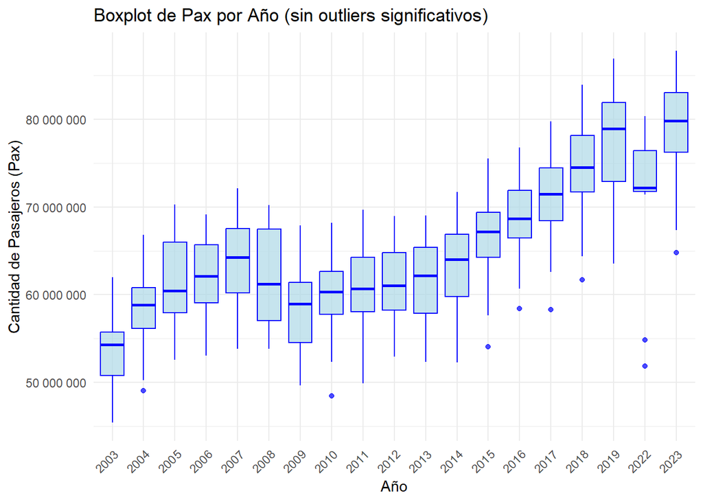

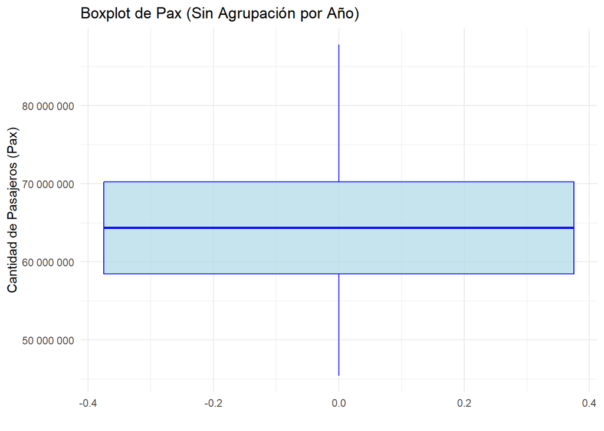

```
## [1] "Media de Pax: 64,667,219"
```

```
## [1] "Mediana de Pax: 64,367,670"
```

```
## [1] "Desviación estándar de Pax: 8,599,340"
```

```
## [1] "Varianza de Pax: 7.394865e+13"
```

```
## [1] "Rango de Pax: 42,398,626"
```